# Tutorial

## Objectives

1. How to define your problem
2. How to choose a appropriate model
3. How to evaluate the model performance
4. How to save your model for re-use

### We are not going to cover

1. classification problem
2. deep learning models

#### In this tutorial, we are going to use the case from Li, G., et al (2019) (https://doi.org/10.1021/acssynbio.9b00099), which tried to predict optimal growth temperature of microoganisms from their proteome.

```python
import pandas as pd
import numpy as np
import random
import matplotlib.pyplot as plt
import seaborn as sns
```

## Overview of Machine Learning

[figure not shown]

## A General protocol for classical Machine Learning analysis

### 1. Define your problem

[figure not shown]

#### Problem: We would like to predict the optimal growth temperature of micro-organisms. This is a regression problem

### 2. Choose models

[figure not shown]

Modified from Yang, K. K., Wu, Z., & Arnold, F. H. (2018). Machine learning-guided directed evolution for protein engineering. Nature Methods. https://doi.org/10.1038/s41592-019-0496-6

#### We have ~5,000 samples. We will start with linear regression and then go for other classical models, like SVM and Random forest

### 3. Do machine learning

[figure not shown]

### 3.1 Feature engineering

Feature engineering is critical for machine learning analysis, especially for classical models. This step is where you can incorporate your domain knowledge.

#### We choose to extract k-mer features from all proteins sequences in a microorganism. The simplest k-mer features are amino-acid frequencies

```python
data = pd.read_csv('../data/AA_classified_2nd_with_head_AAcount.csv',index_col=0)
print(data.shape)
data.head(n=10)
```

```
(5533, 21)
```

|  | A | C | D | E | F | G | H | I | K | L | ... | N | P | Q | R | S | T | V | W | Y | OGT |
| --- | --- | --- | --- | --- | --- | --- | --- | --- | --- | --- | --- | --- | --- | --- | --- | --- | --- | --- | --- | --- | --- |
| 37_allobaculum_stercoricanis_bacteria | 38750.0 | 7190.0 | 31307.0 | 36813.0 | 22821.0 | 33339.0 | 11305.0 | 39487.0 | 34854.0 | 50619.0 | ... | 25891.0 | 19145.0 | 24214.0 | 21014.0 | 31577.0 | 28307.0 | 35229.0 | 5148.0 | 20247.0 | 37.0 |
| 28_shewanella_algae_bacteria | 436013.0 | 49072.0 | 235432.0 | 265441.0 | 165570.0 | 318794.0 | 93876.0 | 220458.0 | 197746.0 | 525289.0 | ... | 156265.0 | 190917.0 | 234489.0 | 227744.0 | 290225.0 | 202503.0 | 266166.0 | 62632.0 | 129478.0 | 28.0 |
| 37_bifidobacterium_saguini_bacteria | 89539.0 | 7428.0 | 51927.0 | 46275.0 | 27916.0 | 63357.0 | 17595.0 | 44947.0 | 33877.0 | 71071.0 | ... | 30201.0 | 37074.0 | 29780.0 | 44294.0 | 50705.0 | 51519.0 | 60905.0 | 11875.0 | 23193.0 | 37.0 |
| 28_ochrobactrum_rhizosphaerae_bacteria | 154306.0 | 10566.0 | 78512.0 | 82184.0 | 54787.0 | 112179.0 | 27803.0 | 83711.0 | 58246.0 | 136657.0 | ... | 44600.0 | 64652.0 | 45327.0 | 87673.0 | 82558.0 | 73821.0 | 100242.0 | 17576.0 | 33072.0 | 28.0 |
| 30_sphingomonas_haloaromaticamans_bacteria | 151083.0 | 7574.0 | 64544.0 | 54968.0 | 36172.0 | 97881.0 | 20993.0 | 53451.0 | 26873.0 | 103804.0 | ... | 25073.0 | 58491.0 | 30154.0 | 82485.0 | 51550.0 | 53158.0 | 72579.0 | 15351.0 | 22882.0 | 30.0 |
| 28_kurthia_massiliensis_bacteria | 76441.0 | 6307.0 | 49673.0 | 61828.0 | 38868.0 | 57876.0 | 20555.0 | 65634.0 | 57999.0 | 84392.0 | ... | 36441.0 | 31300.0 | 38976.0 | 36847.0 | 47612.0 | 57655.0 | 66915.0 | 8171.0 | 33538.0 | 28.0 |
| 30_bacillus_ligniniphilus_bacteria | 75058.0 | 7160.0 | 49107.0 | 81257.0 | 44770.0 | 71396.0 | 22216.0 | 75131.0 | 63834.0 | 100453.0 | ... | 39681.0 | 37836.0 | 40195.0 | 45906.0 | 58012.0 | 54395.0 | 74244.0 | 9989.0 | 33061.0 | 30.0 |
| 29_planococcus_maritimus_bacteria | 79075.0 | 5191.0 | 50060.0 | 73700.0 | 41544.0 | 67676.0 | 19521.0 | 64184.0 | 52394.0 | 92109.0 | ... | 33103.0 | 35069.0 | 36361.0 | 41418.0 | 54500.0 | 49898.0 | 65864.0 | 9546.0 | 29886.0 | 29.0 |
| 37_collinsella_aerofaciens_bacteria | 83598.0 | 11459.0 | 47019.0 | 46939.0 | 25342.0 | 60926.0 | 15549.0 | 37363.0 | 29188.0 | 66406.0 | ... | 22112.0 | 30295.0 | 22181.0 | 45509.0 | 41081.0 | 39455.0 | 58084.0 | 7236.0 | 19593.0 | 37.0 |
| 20_planococcus_halocryophilus_bacteria | 75233.0 | 5573.0 | 50256.0 | 74330.0 | 44149.0 | 67397.0 | 19356.0 | 72069.0 | 60390.0 | 94730.0 | ... | 38516.0 | 34989.0 | 36709.0 | 38661.0 | 58223.0 | 54381.0 | 69203.0 | 9727.0 | 31501.0 | 20.0 |

10 rows × 21 columns

#### Calculate amino acid frequencies for each organism

```python
def cal_aa_fq(data):
    # data is a dataframe with organism names as index and 20 amino acid counts as columns.
    # The last column is OGT
    #
    data_fq = data.copy()
    X = data.values[:,:-1]
    Xfq = np.divide(X,np.sum(X,axis=1).reshape((-1,1)))
    data_fq.loc[:,data.columns[:-1]] = Xfq
    return data_fq
```

```python
data_fq = cal_aa_fq(data)
```

```python
data_fq.head(n=10)
```

|  | A | C | D | E | F | G | H | I | K | L | ... | N | P | Q | R | S | T | V | W | Y | OGT |
| --- | --- | --- | --- | --- | --- | --- | --- | --- | --- | --- | --- | --- | --- | --- | --- | --- | --- | --- | --- | --- | --- |
| 37_allobaculum_stercoricanis_bacteria | 0.072690 | 0.013487 | 0.058728 | 0.069056 | 0.042809 | 0.062539 | 0.021207 | 0.074072 | 0.065381 | 0.094954 | ... | 0.048568 | 0.035913 | 0.045422 | 0.039419 | 0.059234 | 0.053100 | 0.066085 | 0.009657 | 0.037981 | 37.0 |
| 28_shewanella_algae_bacteria | 0.099732 | 0.011225 | 0.053852 | 0.060716 | 0.037872 | 0.072920 | 0.021473 | 0.050427 | 0.045232 | 0.120152 | ... | 0.035743 | 0.043670 | 0.053636 | 0.052093 | 0.066385 | 0.046320 | 0.060882 | 0.014326 | 0.029616 | 28.0 |
| 37_bifidobacterium_saguini_bacteria | 0.109933 | 0.009120 | 0.063754 | 0.056815 | 0.034274 | 0.077788 | 0.021603 | 0.055185 | 0.041593 | 0.087259 | ... | 0.037080 | 0.045518 | 0.036563 | 0.054383 | 0.062254 | 0.063253 | 0.074777 | 0.014580 | 0.028476 | 37.0 |
| 28_ochrobactrum_rhizosphaerae_bacteria | 0.111494 | 0.007634 | 0.056729 | 0.059382 | 0.039586 | 0.081055 | 0.020089 | 0.060486 | 0.042086 | 0.098742 | ... | 0.032226 | 0.046714 | 0.032751 | 0.063348 | 0.059652 | 0.053340 | 0.072430 | 0.012700 | 0.023896 | 28.0 |
| 30_sphingomonas_haloaromaticamans_bacteria | 0.143492 | 0.007193 | 0.061301 | 0.052206 | 0.034355 | 0.092963 | 0.019938 | 0.050765 | 0.025523 | 0.098588 | ... | 0.023813 | 0.055552 | 0.028639 | 0.078341 | 0.048960 | 0.050487 | 0.068932 | 0.014580 | 0.021732 | 30.0 |
| 28_kurthia_massiliensis_bacteria | 0.084591 | 0.006979 | 0.054969 | 0.068420 | 0.043012 | 0.064047 | 0.022747 | 0.072632 | 0.064183 | 0.093390 | ... | 0.040326 | 0.034637 | 0.043132 | 0.040776 | 0.052688 | 0.063802 | 0.074049 | 0.009042 | 0.037114 | 28.0 |
| 30_bacillus_ligniniphilus_bacteria | 0.074185 | 0.007077 | 0.048536 | 0.080312 | 0.044249 | 0.070565 | 0.021958 | 0.074257 | 0.063091 | 0.099284 | ... | 0.039219 | 0.037396 | 0.039727 | 0.045372 | 0.057337 | 0.053762 | 0.073380 | 0.009873 | 0.032676 | 30.0 |
| 29_planococcus_maritimus_bacteria | 0.085203 | 0.005593 | 0.053940 | 0.079412 | 0.044764 | 0.072921 | 0.021034 | 0.069158 | 0.056455 | 0.099247 | ... | 0.035668 | 0.037787 | 0.039179 | 0.044628 | 0.058724 | 0.053765 | 0.070968 | 0.010286 | 0.032202 | 29.0 |
| 37_collinsella_aerofaciens_bacteria | 0.114713 | 0.015724 | 0.064520 | 0.064410 | 0.034774 | 0.083603 | 0.021336 | 0.051270 | 0.040052 | 0.091123 | ... | 0.030342 | 0.041571 | 0.030437 | 0.062448 | 0.056371 | 0.054140 | 0.079703 | 0.009929 | 0.026886 | 37.0 |
| 20_planococcus_halocryophilus_bacteria | 0.078087 | 0.005784 | 0.052163 | 0.077150 | 0.045824 | 0.069954 | 0.020090 | 0.074803 | 0.062681 | 0.098324 | ... | 0.039977 | 0.036316 | 0.038102 | 0.040128 | 0.060432 | 0.056444 | 0.071828 | 0.010096 | 0.032696 | 20.0 |

10 rows × 21 columns

#### Have a look at your dataset

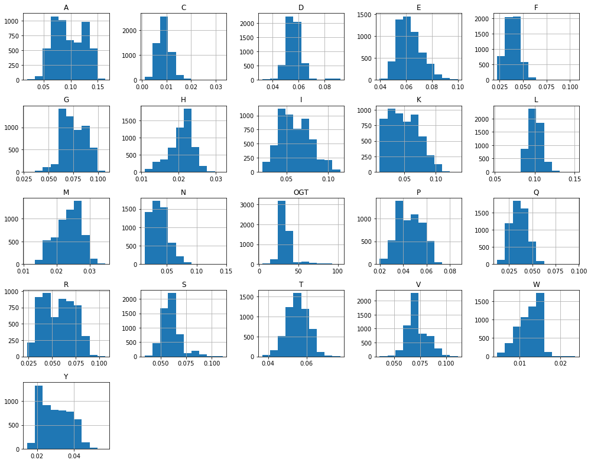

```python
pd.DataFrame.hist(data_fq,bins=10,figsize=(14,11))
plt.tight_layout()
plt.show()
```

### 3.2 Normalization

This step is to ensure that all features values are in a similar scale. There are many ways to normalize the data, like $x_i=\frac{x_i-x_{min}}{x_{max}-x_{min}}$, $x_i=\frac{x_i-\bar{x}}{\sigma}$ and many more.

Important: Do normalization for each feature. Usually it's not necessary to normalized target values.

```python
def normalize(X):
    X_n = np.zeros_like(X)
    k = 0
    for i in range(X.shape[1]):
        x = X[:,i]
        if np.var(x) == 0: continue
        X_n[:,k] = (x-np.mean(x))/np.var(x)**0.5
        k+=1
    return np.around(X_n, decimals=3)
```

```python
X = data_fq.values[:,:-1]
y = data_fq.values[:,-1]
print(X.shape,y.shape)
```

```
(5533, 20) (5533,)
```

#### It would be very slow to run analysis on such a big dataset. For this tutorial, we are going to use 100 samples from this dataset.

```python
random.seed(1)
sel_samples = random.sample(range(X.shape[0]),100)
X_small = X[sel_samples,:]
y_small = y[sel_samples]
print(X_small.shape,y_small.shape)
```

```
(100, 20) (100,)
```

### 3.3 Model evaluation

- Two-level cross-validation (Nested):
  - Inner cross-validation for hyper-parameter optimization
  - Outer cross-validation for model evaluation
- or Split dataset into train, validation, test datasets

```python
from sklearn.ensemble import RandomForestRegressor
from sklearn.model_selection import cross_val_score
from sklearn.model_selection import GridSearchCV
from sklearn.linear_model import LinearRegression as LR
from sklearn import svm
from sklearn.linear_model import ElasticNetCV
from sklearn.tree import DecisionTreeRegressor
from sklearn.linear_model import BayesianRidge
from multiprocessing import cpu_count
```

#### Linear models:

- `sklearn.linear_model.LinearRegression`
- `sklearn.linear_model.ElasticNetCV`
- `sklearn.linear_model.BayesianRidge`

#### Non-linear models:

- `sklearn.linear_model.svm.SVR`
- `sklearn.linear_model.DecisionTreeRegressor`
- `sklearn.linear_model.RandomForestRegressor`

...

#### For regression analysis, two commonly used metrics to evaluation model performance are coefficient of determination ($R^2$) and mean squared error (MSE)

```python
def do_cross_validation(X,y,model,n_jobs=-1,cv=2):
    scores = cross_val_score(model,X,y,scoring='r2',cv=cv,n_jobs=n_jobs)
    return [np.mean(scores),np.std(scores)]
```

```python
def lr():
    return LR()
```

```python
def elastic_net():
    return ElasticNetCV(n_jobs=-1,cv=2)
```

```python
def bayesridge():
    # There are several hyper-parameters in this model.
    # https://scikit-learn.org/stable/modules/generated/sklearn.linear_model.BayesianRidge.html
    # In this tutorial, default ones are used
    model = BayesianRidge()
    return model
```

```python
def svr():
    parameters={
                'C':np.logspace(-5,10,num=16,base=2.0),
                'epsilon':[0,0.01,0.1,0.5,1.0,2.0,4.0]
                }
    svr = svm.SVR(kernel='rbf')
    model = GridSearchCV(svr,parameters,n_jobs=-1,cv=2)
    return model
```

```python
def random_forest():
    # You can choose as many trees as you can, depending on your computational power. Usually 1000 would be a
    # reasonable choice. This also depend on the complexity of your problem.
    #
    parameters = {
                    'max_features':np.arange(0.1,1.1,0.1)
    }
    rf = RandomForestRegressor(n_estimators=100,verbose =0,n_jobs=-1)
    model=GridSearchCV(rf,parameters,n_jobs=1,cv=2)
    return model
```

```python
models = {'Linear':lr(),
         'ElasticNetCV':elastic_net(),
         'BayesianRidge':bayesridge(),
         'SVR':svr(),
         'RandomForestRegressor':random_forest()}
model_names = list(models.keys())
R2s = list()
for name in model_names: R2s.append(do_cross_validation(X_small,y_small,models[name],n_jobs=-1))
R2s = np.array(R2s)
```

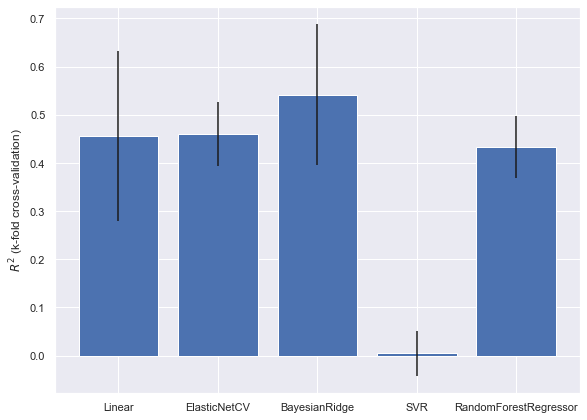

```python
plt.figure(figsize=(8,6))
sns.set()
plt.bar(np.arange(len(models)),R2s[:,0],yerr=R2s[:,1])
plt.tight_layout()
plt.xticks(np.arange(len(models)),model_names)
plt.ylabel('$R^2$ (k-fold cross-validation)')
plt.show()
```

```python
# Get optimized hyper-parameters
model = random_forest()
model.fit(X_small,y_small)
best_params = model.best_params_
```

```python
best_params
```

```
{'max_features': 0.30000000000000004}
```

```python
rf = RandomForestRegressor(n_estimators=100,**best_params)
rf.fit(X_small,y_small)
```

```
RandomForestRegressor(bootstrap=True, criterion='mse', max_depth=None,
                      max_features=0.30000000000000004, max_leaf_nodes=None,
                      min_impurity_decrease=0.0, min_impurity_split=None,
                      min_samples_leaf=1, min_samples_split=2,
                      min_weight_fraction_leaf=0.0, n_estimators=100,
                      n_jobs=None, oob_score=False, random_state=None,
                      verbose=0, warm_start=False)
```

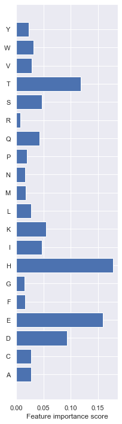

```python
plt.figure(figsize=(3,10))
plt.barh(np.arange(len(rf.feature_importances_)),rf.feature_importances_)
plt.yticks(np.arange(len(rf.feature_importances_)), data_fq.columns[:-1])
plt.xlabel('Feature importance score')
plt.tight_layout()
plt.show()
```

### 3.5 Publish your model

You have to save at least following information

- Normalizer
- Trained model

```
class final_model:
    def __init__(self,predictor,normalizer,...):
        self.predictor = predictor
        self.normailzer = normalizer
        ...

    def normalize(self):
        xxx

    def extract_features(self,inputfile):
        xxx

    def predict(self,input_samples):
```

#### Then one can save the model with `pickle`

```
import pickle

best_model = final_model(predictor,normalizer,...)
outfile = 'model.pkl'
pickle.dump(best_model,open(outfile,'wb'))
```

#### To re-use the model

```
best_model = pickle.load(open('model.pkl','rb'))
```

### An example

https://github.com/EngqvistLab/Tome/tree/devel2